# Week 6 KNN and Ensemble Learning

## Theory and Practice

### by Ying Lin, Ph.D.

## Outline

- K Nearest Neighbor algorithm
- Ensemble learning strategy
- Bagging: bootstrapping, random forest
- Boosting: Adaptive Boosting (AdaBoost), Gradient Boosting Machine (GBM) and eXtreme Gradient Boosting (XGBoost)
- Python demo

## Overview of K Nearest Neighbor (KNN)

- Key ideas: data points closer to each other tend to behave similarly
- Lazy learner: no active model-building is done with training dataset
  - Vs. active learner
  - No training time, long prediction time. Too slow for an online system.
- Instance-based and distance-based learning
  - Sensitive towards irrelevant attributes
  - Sensitive towards outliers and noisy data
  - Requires data preprocessing: conversion from categorical to numerical attributes, standardization, normalization
- Non-parametric method: no assumption of data distribution
  - Could detect highly complex nonlinear decision boundary

## Variance vs. Bias Tradeoff

- $Error = Variance + Bias$
- Variance: stability of model and predictions
- Bias: accuracy of the model/methodology
- Overfitting: high variance, low bias
- "No Free Lunch" theorem: trade off between variance and bias, no single algorithm will outperform other algorithms on all datasets

## Hyper-Parameters of KNN

- Number of neighbors (*K*)
  - Too large: high bias
  - Too small: high variance (overfitting)
- Distance functions
  - Euclidean
  - Manhattan
  - Minkowski

## Ensemble Learning Motivations

- Additive model: combine multiple classifiers together and take consensus
- Different mechanisms to produce multiple classifiers from the same datasets
  - Bagging (Bootstrap AGGregating): create multiple samples (with replacement) from the original dataset and train multiple classifiers in parallel; reduce variance
  - Boosting: an iterative algorithm that induces base (weak) learners sequentially (e.g. assigns different weights to the data points to focus on those tougher cases): reduce bias
  - Random Forest: train large number of decision stumps (smaller decision trees with less nodes) and use committee majority voting to decide the final classification

## Illustratration of Benefit of Ensemble Learning

- Wisdom of the mass
- Case study
  - 25 weak learners with 30% error rate
  - What is the error rate of the ensemble classifier

## Bagging vs. Boosting

[figure not shown]

## Bagging: Bootstrap Resampling Strategy

- Sampling with replacement
- 0.632 Rule
  - Roughly $1/3$ data won't be included in the bootstrap sample, therefore used for validation purpose
  - $lim_{n\rightarrow\infty}(1-\frac{1}{n})^n = e^{-1}\approx 0.368$

## Algorithms: Random Forest

- Produce a distribution of simple ML models on subsets of the original data
- Combine the distribution into one "aggregated" model
- Train
  1. Pick $k$ features from the dataset with $m$ features ($k \ll m$, e.g. $\sqrt{m}$)
  2. Among $k$ features, pick the one that maximizes information gain (or gain ratio) and use it as the node to further split the data
  3. Repeat step 2 to derive individual decision tree
  4. Repeat step 1 - 3 to generate $n$ number of trees
- Predict
  1. Apply each individual tree from the $n$ random trees to the test data point and derive the outcomes and store the $n$ predicted outcome
  2. Calculate the weight for each predicted outcome
  3. Consider the outcome with the highest weight as the final classication/prediction for the test data point

## Adaptive Boosting (AdaBoosting) Illustration

[figure not shown]

## Gradient Boosting Regressor Algorithm

[figure not shown]

## GBM/XGB

- Gradient Boosting Machine (GBM)
  - Additive model
  - Boost performance of weak learners to strong learners additively and sequentially
  - Use gradient descent to construct new base learners that minimize loss function
  - Gradient descent is used in the function space, instead of in the parameter space (e.g. backpropagation in neural network)
- Extreme Gradient Boosting (XGB) improves upon GBM
  - Faster using parallel computing
  - Regularization (hyperparameters such as $\alpha$, $\lambda$), pruning ($\gamma$), cross validation enabled, etc.

## Analogy of GBM

[figure not shown]

## Visualize GBM

[figure not shown]

## Ensemble Model Hyper-Parameters

- tree-related parameters: max_depth, min_samples_split, min_samples_leaf, etc.
- max_features: optional integer for number of features to randomly select at each split, such as $\sqrt{n}$ and $n$ is the number of features, used for random forest or GBM.
- n_estimators: number of classifiers
- learning_rate ($\eta$): GBM/XGB, gradient descent algorithm
- objective function/loss: classification vs. regression
- subsample, etc.

## Property of the Algorithms: Pros and Cons

- Pros
  - Perform well on a wide variety of tasks
  - Some ensemble methods such as random forest are robust to overfitting
- Cons
  - More hyper-parameters to tune
  - Interpretability issue
  - Might be sensitive to outliers/noises and overfitting: boosting
  - Higher computational cost

```python
## Load in Necessary Python packages

import numpy as np
import pandas as pd
from sklearn.model_selection import train_test_split, ShuffleSplit, cross_val_score
from sklearn.neighbors import KNeighborsClassifier
from sklearn import metrics
from scipy.spatial.distance import cdist
from sklearn.pipeline import make_pipeline
import matplotlib.pyplot as plt
```

```python
## Data Preparation and KNN modeling

diabetes = pd.read_csv("https://datahub.io/machine-learning/diabetes/r/diabetes.csv")
X = diabetes.drop('class', axis=1)
y = diabetes['class']
X_train, X_test, y_train, y_test = train_test_split(X, y, test_size=0.3, random_state=16)
classifier = KNeighborsClassifier()
classifier.fit(X_train, y_train)
y_pred = classifier.predict(X_test)
print(f"Accuracy: {round(metrics.accuracy_score(y_test, y_pred)*100, 2)}%")
df_confusion = pd.crosstab(y_test, y_pred)
df_confusion
```

```
Accuracy: 72.29%
```

| col_0 class | tested_negative | tested_positive |
| --- | --- | --- |
| tested_negative | 124 | 23 |
| tested_positive | 41 | 43 |

```python
## Preprocess Data: Standardization/Normalization

import warnings
warnings.filterwarnings("ignore")

from sklearn.preprocessing import StandardScaler
scaler = StandardScaler()
scaler.fit(X_train)

X_train_std = scaler.transform(X_train)
X_test_std = scaler.transform(X_test)
pd.DataFrame(X_train_std).mean()
X_train_std.std()
X_train.mean()
X_train.std()
```

```
preg      3.309324
plas     32.972357
pres     19.563244
skin     16.123755
insu    115.457871
mass      8.165811
pedi      0.332525
age      11.459534
dtype: float64
```

```python
## KNN Performance Evaluation

classifier_std = KNeighborsClassifier()
classifier_std.fit(X_train_std, y_train)
y_pred_std = classifier_std.predict(X_test_std)
pd.Series(y_pred_std).value_counts()
value, count = np.unique(y_pred_std, return_counts=True)
pd.DataFrame({"value": value, "count": count})
print(f"Accuracy: {round(metrics.accuracy_score(y_test, y_pred_std)*100, 2)}%")
```

```
Accuracy: 74.89%
```

```python
## Use Pipeline to Streamline the Analysis

knn_pipe = make_pipeline(StandardScaler(), KNeighborsClassifier())
knn_pipe.fit(X_train, y_train)
', '.join(dir(knn_pipe))
knn_pipe.get_params()
knn_pipe.set_params(kneighborsclassifier__n_neighbors=8)
pipe_pred = knn_pipe.predict(X_test)
pd.Series(pipe_pred).value_counts()
```

```
Pipeline(memory=None,
         steps=[('standardscaler',
                 StandardScaler(copy=True, with_mean=True, with_std=True)),
                ('kneighborsclassifier',
                 KNeighborsClassifier(algorithm='auto', leaf_size=30,
                                      metric='minkowski', metric_params=None,
                                      n_jobs=None, n_neighbors=5, p=2,
                                      weights='uniform'))],
         verbose=False)
```

[output not shown]

```
{'memory': None,
 'steps': [('standardscaler',
   StandardScaler(copy=True, with_mean=True, with_std=True)),
  ('kneighborsclassifier',
   KNeighborsClassifier(algorithm='auto', leaf_size=30, metric='minkowski',
                        metric_params=None, n_jobs=None, n_neighbors=5, p=2,
                        weights='uniform'))],
 'verbose': False,
 'standardscaler': StandardScaler(copy=True, with_mean=True, with_std=True),
 'kneighborsclassifier': KNeighborsClassifier(algorithm='auto', leaf_size=30, metric='minkowski',
                      metric_params=None, n_jobs=None, n_neighbors=5, p=2,
                      weights='uniform'),
 'standardscaler__copy': True,
 'standardscaler__with_mean': True,
 'standardscaler__with_std': True,
 'kneighborsclassifier__algorithm': 'auto',
 'kneighborsclassifier__leaf_size': 30,
 'kneighborsclassifier__metric': 'minkowski',
 'kneighborsclassifier__metric_params': None,
 'kneighborsclassifier__n_jobs': None,
 'kneighborsclassifier__n_neighbors': 5,
 'kneighborsclassifier__p': 2,
 'kneighborsclassifier__weights': 'uniform'}
```

```
Pipeline(memory=None,
         steps=[('standardscaler',
                 StandardScaler(copy=True, with_mean=True, with_std=True)),
                ('kneighborsclassifier',
                 KNeighborsClassifier(algorithm='auto', leaf_size=30,
                                      metric='minkowski', metric_params=None,
                                      n_jobs=None, n_neighbors=8, p=2,
                                      weights='uniform'))],
         verbose=False)
```

```
tested_negative    185
tested_positive     46
dtype: int64
```

```python
## Get Repeated Hold Out Accurary of Model

cv = ShuffleSplit(n_splits=100, test_size=0.3, random_state=16)
from sklearn.model_selection import KFold
cv = KFold(n_splits=10, shuffle=True, random_state=16)
cross_val_score(knn_pipe, X_train, y_train, cv=cv).mean()
```

```
0.7022361984626136
```

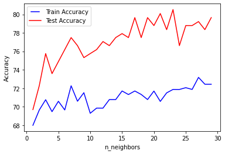

```python
## Sensitivity Analysis

from matplotlib.legend_handler import HandlerLine2D
neighbors = list(range(1, 30))
train_results = []
test_results = []
for n in neighbors:
  model = KNeighborsClassifier(n_neighbors=n)
  model.fit(X_train_std, y_train)
  train_pred = model.predict(X_train_std)
  acc = cross_val_score(model, X_train_std, y_train, cv=cv).mean()*100
  train_results.append(acc)
  y_pred = model.predict(X_test_std)
  acc_test = round(metrics.accuracy_score(y_test, y_pred)*100, 2)
  test_results.append(acc_test)

line1, = plt.plot(neighbors, train_results, 'b', label="Train Accuracy")
line2, = plt.plot(neighbors, test_results, 'r', label="Test Accuracy")
plt.legend(handler_map={line1: HandlerLine2D(numpoints=2)})
plt.ylabel("Accuracy")
plt.xlabel("n_neighbors")
plt.show()
```

```python
## Ensemble Learning - Bagging

from sklearn.ensemble import BaggingClassifier
from sklearn.tree import DecisionTreeClassifier

cart = DecisionTreeClassifier()
num_trees = 100
model = BaggingClassifier(base_estimator=cart, n_estimators=num_trees, random_state=16)
results = cross_val_score(model, X_train_std, y_train, cv=cv)
print(f"Accuracy: {round(results.mean()*100, 2)}%")
```

```
Accuracy: 71.73%
```

```python
## Random Forest

from sklearn.ensemble import RandomForestClassifier

model = RandomForestClassifier(n_estimators=num_trees, max_features=5, random_state=16)
results = cross_val_score(model, X_train_std, y_train, cv=cv)
print(f"Accuracy: {round(results.mean()*100, 2)}%")
model
```

```
Accuracy: 73.59%
```

```
RandomForestClassifier(bootstrap=True, ccp_alpha=0.0, class_weight=None,
                       criterion='gini', max_depth=None, max_features=5,
                       max_leaf_nodes=None, max_samples=None,
                       min_impurity_decrease=0.0, min_impurity_split=None,
                       min_samples_leaf=1, min_samples_split=2,
                       min_weight_fraction_leaf=0.0, n_estimators=100,
                       n_jobs=None, oob_score=False, random_state=16, verbose=0,
                       warm_start=False)
```

```python
## Feature Importance

model.fit(X_train_std, y_train)
feature_imp = pd.DataFrame(model.feature_importances_, index=X_train.columns,
columns=['importance']).sort_values('importance', ascending=False)
feature_imp
```

|  | importance |
| --- | --- |
| plas | 0.299555 |
| mass | 0.192756 |
| pedi | 0.133711 |
| age | 0.105525 |
| pres | 0.083997 |
| preg | 0.067676 |
| insu | 0.059420 |
| skin | 0.057359 |

```python
## AdaBoosting

from sklearn.ensemble import AdaBoostClassifier
model = AdaBoostClassifier(n_estimators=num_trees, random_state=16)
results = cross_val_score(model, X_train_std, y_train, cv=cv)
print(f"Accuracy: {round(results.mean()*100, 2)}%")
model
```

```
Accuracy: 72.08%
```

```
AdaBoostClassifier(algorithm='SAMME.R', base_estimator=None, learning_rate=1.0,
                   n_estimators=100, random_state=16)
```

```python
## GBM

from sklearn.ensemble import GradientBoostingClassifier as gbm
model = gbm(n_estimators=num_trees, random_state=16)
results = cross_val_score(model, X_train_std, y_train, cv=cv)
print(f"Accuracy for GBM: {round(results.mean()*100, 2)}%")
model
```

```
Accuracy for GBM: 72.47%
```

```
GradientBoostingClassifier(ccp_alpha=0.0, criterion='friedman_mse', init=None,
                           learning_rate=0.1, loss='deviance', max_depth=3,
                           max_features=None, max_leaf_nodes=None,
                           min_impurity_decrease=0.0, min_impurity_split=None,
                           min_samples_leaf=1, min_samples_split=2,
                           min_weight_fraction_leaf=0.0, n_estimators=100,
                           n_iter_no_change=None, presort='deprecated',
                           random_state=16, subsample=1.0, tol=0.0001,
                           validation_fraction=0.1, verbose=0,
                           warm_start=False)
```

```python
## Model Tuning

from sklearn.model_selection import GridSearchCV
param_grid = {'learning_rate': np.arange(0.02, 0.1, 0.02),
              'n_estimators': range(60, 160, 50),
              'max_depth': range(2, 5)}
clf = GridSearchCV(gbm(), param_grid)
clf.fit(X_train_std, y_train)
```

```
GridSearchCV(cv=None, error_score=nan,
             estimator=GradientBoostingClassifier(ccp_alpha=0.0,
                                                  criterion='friedman_mse',
                                                  init=None, learning_rate=0.1,
                                                  loss='deviance', max_depth=3,
                                                  max_features=None,
                                                  max_leaf_nodes=None,
                                                  min_impurity_decrease=0.0,
                                                  min_impurity_split=None,
                                                  min_samples_leaf=1,
                                                  min_samples_split=2,
                                                  min_weight_fraction_leaf=0.0,
                                                  n_estimators=100,
                                                  n_iter_n...nge=None,
                                                  presort='deprecated',
                                                  random_state=None,
                                                  subsample=1.0, tol=0.0001,
                                                  validation_fraction=0.1,
                                                  verbose=0, warm_start=False),
             iid='deprecated', n_jobs=None,
             param_grid={'learning_rate': array([0.02, 0.04, 0.06, 0.08]),
                         'max_depth': range(2, 5),
                         'n_estimators': range(60, 160, 50)},
             pre_dispatch='2*n_jobs', refit=True, return_train_score=False,
             scoring=None, verbose=0)
```

```python
## Model Tuning (2)

print(f"Accuracy for best GBM: {round(clf.best_score_*100, 2)}%")
for key, val in clf.best_params_.items():
  print(f"Best hyperparameter is {key}: {val}")
```

```
Accuracy for best GBM: 77.11%
Best hyperparameter is learning_rate: 0.08
Best hyperparameter is max_depth: 2
Best hyperparameter is n_estimators: 60
```